# Connected or Disconnected?

An Examination of the Relationship between Social Media Use and Feelings of Isolation in China

Jason Gainous[^1]

Andrew W. MacDonald[^2]

March 25, 2022

# 1 Social Isolation in China

## 1.1 Introduction

Research is quite mixed when it comes to identifying the relationship between social media use and feelings of isolationism. Early research suggested that the internet would build social capital, or an interconnectedness between people, and that social media platforms were the ultimate way to bring people together. Since then, research indicates that the effect may be the opposite for many. Social media may encourage social isolation, and ultimately, social media users may feel more disconnected from others than those who do not use social media. We know very little about this phenomenon in China. China presents an interesting case because the internet is bifurcated to some degree – there is the Chinese internet and the outside internet available via VPNs. Being connected to the outside world may lessen feelings of isolation, or it may increase these feelings because digital exposure to a world is much larger than that in people’s immediate environment without the ability to have in-person connection to may make one feel isolated. Interestingly, and somewhat ironically though, it may also matter, too, whether someone lives in a city. Research has suggested that urban living can actually lead to feelings of isolation.

## 1.2 Data

Our data are based on a random Internet survey conducted by Qualtrics from November 25 to December 2, 2015. We designed the instrument, content and structure. After we designed the instrument in English and translated it into Chinese, we entered the questions into the graphical interface provided from our survey provider, Qualtrics. We were careful at this stage to make the formatting clear, and to distribute the questions across numerous pages to prevent overwhelming respondents with too many questions at once. This helped us achieve a high completion and response rate. Additionally, we were particularly attentive to the possibility of question order effects. Many of the questions are sensitive and could cue responses to subsequent questions. We grouped and placed questions strategically to limit any such potential for response bias. Once we settled on the design, Qualtrics administered the survey in November 2015. They recruit a large pool of respondents for various survey projects through online advertising on websites such as local portals, search engines, social networking services, and/or online shopping services. Panelists who update their profiles at least once every 6 months are randomly invited to participate in surveys for which they qualify. Online points are awarded to the corresponding panelists, which they may accumulate and exchange for cash or various other country-specific gifts to serve as an incentive for completion. This number of points is based on the length of the survey. Ours had over fifty questions, so respondents received a relatively high number of points.

While our sample was randomly selected, the sampling frame was based only on Internet users that Qualtrics can access. Qualtrics recruits their frame subjects through online advertising on websites such as local portals, search engines, social networking services, and/or online shopping services. We do not contend that our sample is representative of the Chinese population, as the method of obtaining respondents obviously greatly limits those citizens with little or no access to the Internet. That said, we are comfortable that our sample is generally representative of Chinese Internet users. Given that our research focus centers on Internet effects, it makes sense to have a large sample of Internet users. A sampling frame including the entire Chinese population did not make sense for this research. Half of the population do not regularly access the Internet according to World Bank and China Internet Network Information Center (CNNIC) data as of late 2015 when we conducted our survey. Using a sample of the entire population could potentially limit the degrees of freedom in our models and the marginals of nuanced measures of digital media use would likely become too small to have any value. Thus, the large sample of Internet users adds to our confidence in the inferences throughout the book.

## 1.3 Summary statistics

### 1.3.1 Summary stats table

|  | N | Missing |  | Mean | SD |  | Min | Q1 | Median | Q3 | Max |
| --- | --- | --- | --- | --- | --- | --- | --- | --- | --- | --- | --- |
| connected | 2283 | 9 |  | 0.41 | 0.20 |  | 0 | 0.25 | 0.42 | 0.50 | 1 |
| gen_social_med | 2210 | 82 |  | 0.63 | 0.17 |  | 0 | 0.57 | 0.67 | 0.73 | 1 |
| urbanicity | 2263 | 29 |  | 0.68 | 0.33 |  | 0 | 0.50 | 0.75 | 1.00 | 1 |
| ses | 2286 | 6 |  | 0.61 | 0.14 |  | 0 | 0.48 | 0.65 | 0.73 | 1 |
| female | 2288 | 4 |  | 0.47 | 0.50 |  | 0 | 0.00 | 0.00 | 1.00 | 1 |
| CCP_member | 2284 | 8 |  | 0.24 | 0.43 |  | 0 | 0.00 | 0.00 | 0.00 | 1 |
| age | 2287 | 5 |  | 0.37 | 0.15 |  | 0 | 0.26 | 0.35 | 0.45 | 1 |
| jump_wall | 1986 | 306 |  | 0.32 | 0.32 |  | 0 | 0.00 | 0.33 | 0.67 | 1 |

### 1.3.2 Correlations

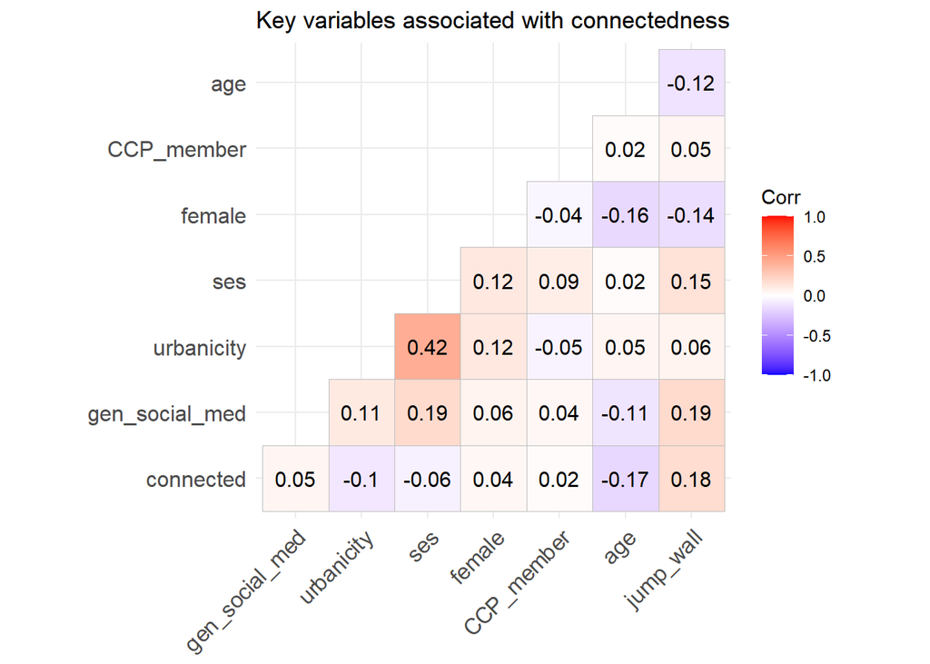

## 1.4 Models

|  | connected |  | connected |  | connected |  |
| --- | --- | --- | --- | --- | --- | --- |
| Predictors | Estimates | p | Estimates | p | Estimates | p |
| (Intercept) | 0.50 | **<0.001** | 0.43 | **<0.001** | 0.53 | **<0.001** |
| gen_social_med | 0.02 | 0.484 | 0.13 | **0.020** | -0.03 | 0.423 |
| urbanicity | -0.05 | **<0.001** | 0.06 | 0.270 | -0.05 | **0.001** |
| SES | -0.09 | **0.013** | -0.09 | **0.015** | -0.10 | **0.008** |
| Female | 0.03 | **0.004** | 0.03 | **0.004** | 0.03 | **0.005** |
| CCP | 0.01 | 0.478 | 0.01 | 0.456 | 0.01 | 0.501 |
| Age | -0.17 | **<0.001** | -0.17 | **<0.001** | -0.17 | **<0.001** |
| jump_wall | 0.11 | **<0.001** | 0.11 | **<0.001** | 0.01 | 0.924 |
| gen_social_med:urbanicity |  |  | -0.17 | **0.024** |  |  |
| gen_social_med:jump_wall |  |  |  |  | 0.17 | **0.039** |
| Observations | 1889 |  | 1889 |  | 1889 |  |
| R<sup>2</sup> / R<sup>2</sup> adjusted | 0.071 / 0.068 |  | 0.074 / 0.070 |  | 0.073 / 0.069 |  |

## 1.5 Margin plots

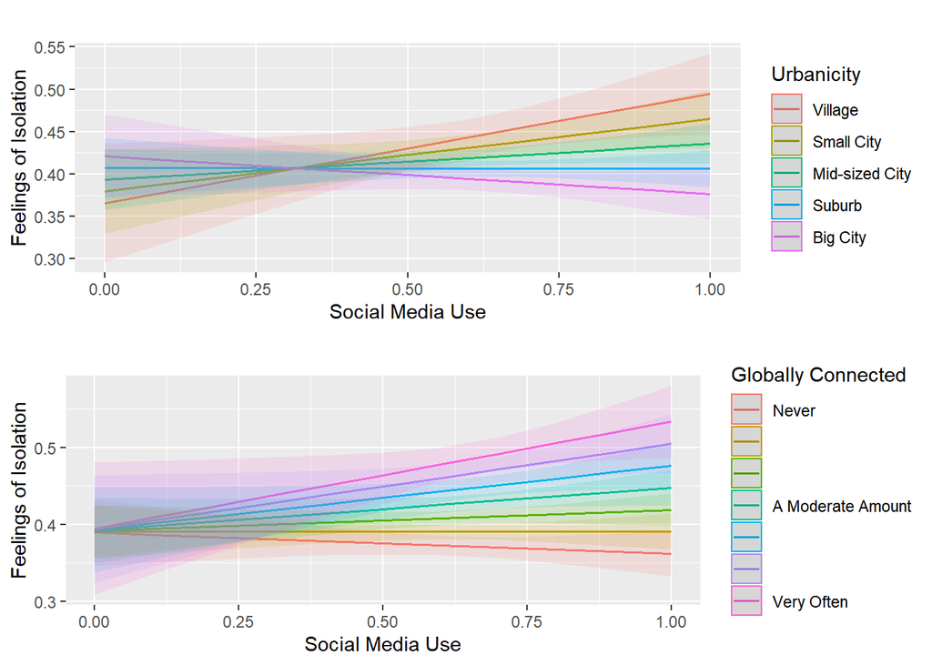

[^1]: Duke Kunshan University, jason.gainous@louisville.edu
[^2]: Duke Kunshan University, andrew.macdonald@dukekunshan.edu.cn